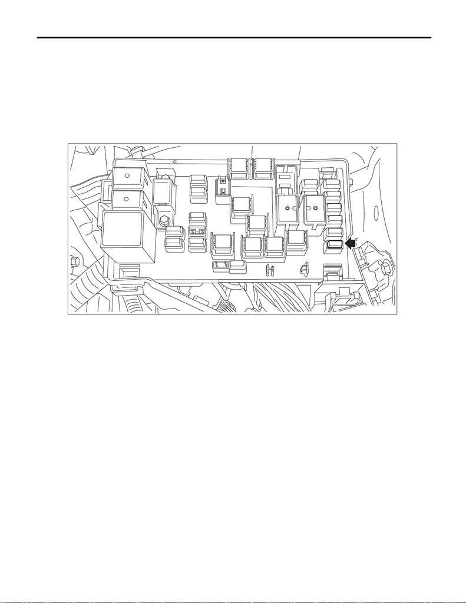

FU(w/o STI)-146

Fuel

FUEL INJECTION (FUEL SYSTEMS)

32.Fuel

A: PROCEDURE

1. RELEASING OF FUEL PRESSURE

WARNING:

Place “NO OPEN FLAMES” signs near the working area.

CAUTION:

Be careful not to spill fuel.

1) Remove the fuse of fuel pump from main fuse box.

2) Start the engine and run it until it stalls.

3) After the engine stalls, crank it for five more seconds.

4) Turn the ignition switch to OFF.

5) Install the fuse of fuel pump to the main fuse box.

6) Make sure that the malfunction indicator light is not lit.

NOTE:

When the fuel pressure is released, the malfunction indicator light illuminates and DTC (P0087) may be

stored in ECM. When the malfunction indicator light has illuminated, perform the Clear Memory Mode. <Ref.

to EN(w/o STI)(diag)-61, Clear Memory Mode.>

2. DRAINING FUEL (WITH SUBARU SELECT MONITOR)

WARNING:

Place “NO OPEN FLAMES” signs near the working area.

CAUTION:

Be careful not to spill fuel.

NOTE:

• If the fuel pump cannot be driven, refer to the procedures for draining from the fuel filler hose. <Ref. to

FU(w/o STI)-149, DRAINING FUEL (THROUGH THE FUEL FILLER HOSE), PROCEDURE, Fuel.>

• Be careful not to let the battery run-out.

• Be aware that the fuel may remain in the fuel tank after draining the fuel.

1) Release the fuel pressure. <Ref. to FU(w/o STI)-146, RELEASING OF FUEL PRESSURE, PROCE-

DURE, Fuel.>

ME-05064

15WRX_STI_US_EN.book 146 ページ ２０１５年２月１３日 金曜日 午前１１時２０分

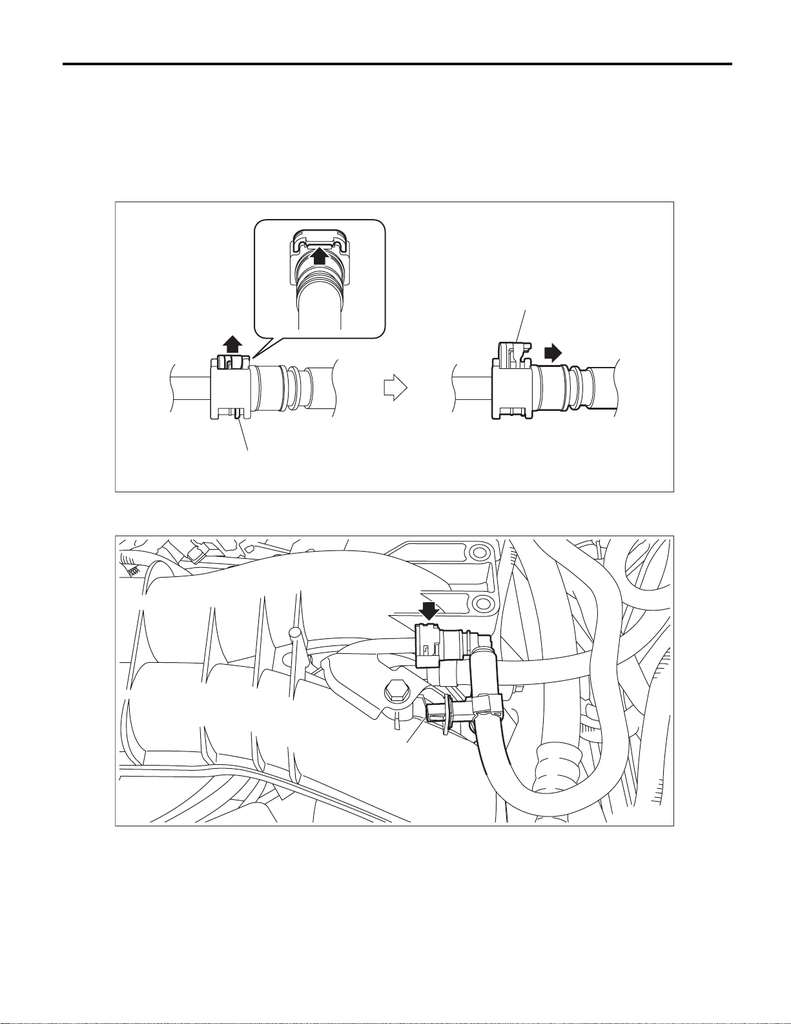

FU(w/o STI)-147

Fuel

FUEL INJECTION (FUEL SYSTEMS)

2) Disconnect the fuel delivery tube from the fuel pipe assembly, and remove the clip (A) securing the fuel de-

livery tube.

CAUTION:

• Be careful not to spill fuel.

• Catch the fuel from the tubes using a container or cloth.

NOTE:

Disconnect the quick connector as shown in the figure.

3) Connect ST to the fuel delivery tube.

ST 18471AA000 FUEL PIPE ADAPTER

4) Connect the gasoline proof hose to ST and put the end of the hose in the container.

(a) Slider

FU-07796

(a)

(a)

FU-08319

(A)

15WRX_STI_US_EN.book 147 ページ ２０１５年２月１３日 金曜日 午前１１時２０分

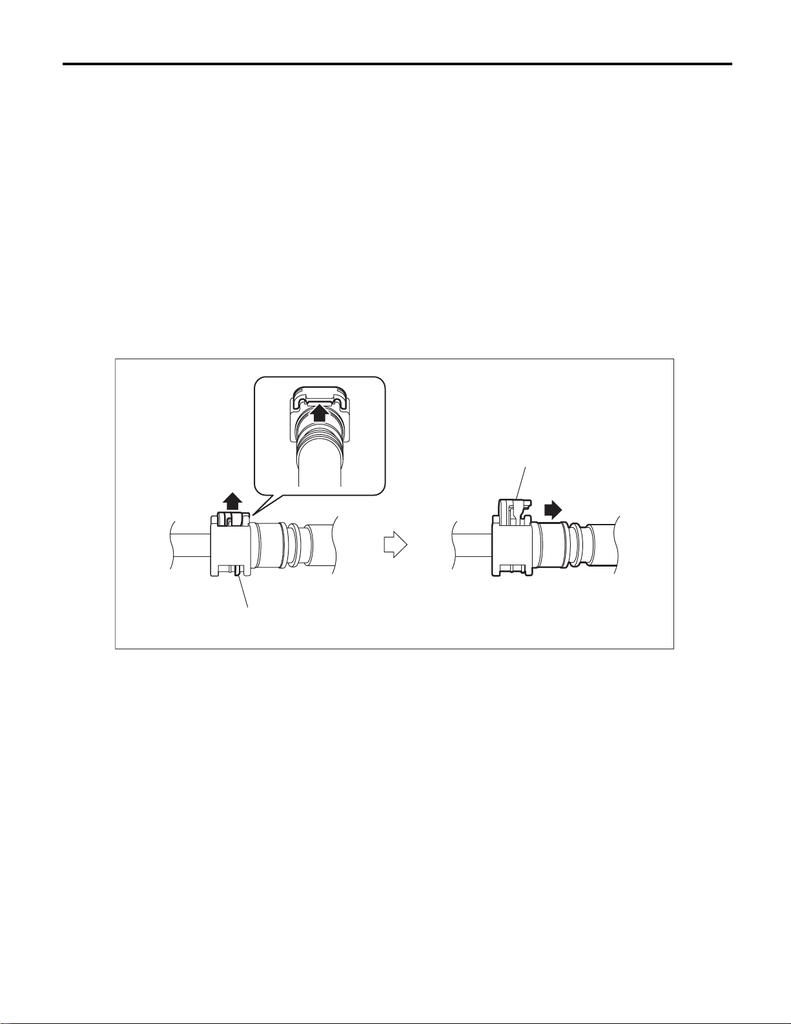

FU(w/o STI)-148

Fuel

FUEL INJECTION (FUEL SYSTEMS)

5) Drive the fuel pump and drain the fuel using Subaru Select Monitor.

CAUTION:

Be careful not to spill fuel.

NOTE:

For detailed operation procedures, refer to “PC application help for Subaru Select Monitor”.

6) Install the related parts in the reverse order after draining the fuel.

CAUTION:

• Be careful not to spill fuel.

• Catch the fuel from the tubes using a container or cloth.

• Check that there is no damage or dust on the quick connector. If necessary, clean the seal surface

of the pipe.

• When connecting the quick connector, make sure to insert it all the way in before locking the slider.

• When it is difficult to lock the slider, check that the connector is fully inserted.

• After locking the slider, check again that the quick connector is securely connected.

NOTE:

• Disconnect the quick connector on the fuel delivery tube as shown in the figure.

(a) Slider

FU-07796

(a)

(a)

15WRX_STI_US_EN.book 148 ページ ２０１５年２月１３日 金曜日 午前１１時２０分

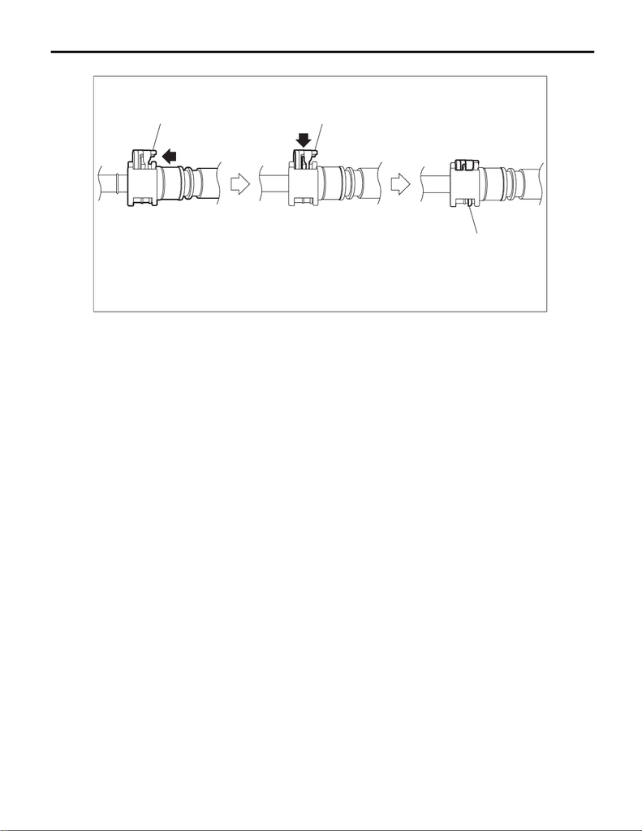

FU(w/o STI)-149

Fuel

FUEL INJECTION (FUEL SYSTEMS)

• Connect the quick connector on the fuel delivery tube as shown in the figure.

3. DRAINING FUEL (THROUGH THE FUEL FILLER HOSE)

WARNING:

Place “NO OPEN FLAMES” signs near the working area.

CAUTION:

• Be careful not to spill fuel.

• Fuel may remain in the fuel filler pipe. Drain the fuel from the fuel filler pipe through the fill opening

using the gasoline proof pump and the gasoline proof hose (ø10 or less) before the operation.

NOTE:

Be aware that the fuel may remain in the fuel tank after draining the fuel.

1) Lift up the vehicle.

2) Open the fuel filler lid and remove the fuel filler cap.

NOTE:

This operation is required to release the inner pressure of the fuel tank.

3) Drain the fuel from the fuel filler pipe through the filler opening using the gasoline proof pump and the gas-

oline proof hose (ø10 or less).

(a) Slider

FU-07797

(a)

(a)

(a)

15WRX_STI_US_EN.book 149 ページ ２０１５年２月１３日 金曜日 午前１１時２０分

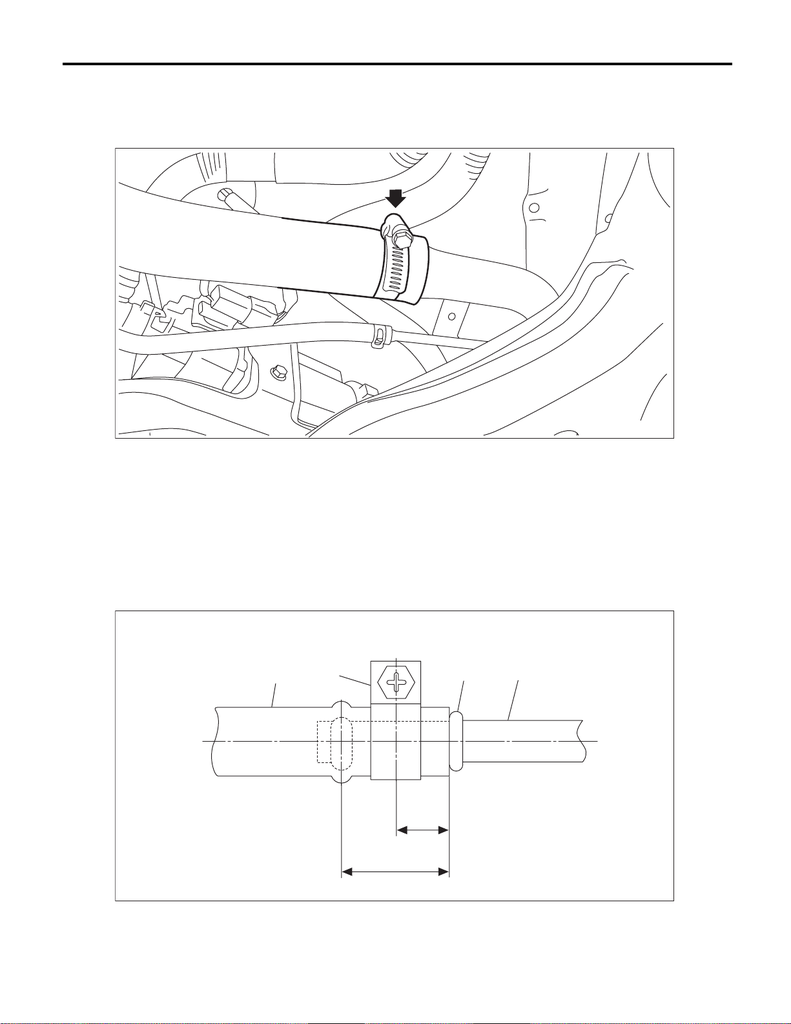

FU(w/o STI)-150

Fuel

FUEL INJECTION (FUEL SYSTEMS)

4) Disconnect the fuel filler hose from the fuel filler pipe assembly.

CAUTION:

• Be careful not to spill fuel.

• Catch the fuel from hoses using a container or cloth.

5) Set the container under the vehicle and insert the gasoline proof hose (ø10 or less) into the fuel filler hose

to drain the fuel.

CAUTION:

Be careful not to spill fuel.

6) Install the related parts in the reverse order after draining the fuel.

NOTE:

Correctly insert the fuel filler hose to the spool, and then install the clamp as shown.

Tightening torque:

2.5 N·m (0.3 kgf-m, 1.8 ft-lb)

(1) Fuel filler hose (3) Spool (4) Fuel filler pipe

(2) Clamp

FU-08361

(1)

(2)

(4)

L

L/2

(3)

FU-06055

15WRX_STI_US_EN.book 150 ページ ２０１５年２月１３日 金曜日 午前１１時２０分